# Tidying your data

SISBID 2016

Di Cook (dicook@monash.edu, @visnut); Heike Hofmann (heike.hofmann@gmail.com, @heike_hh); edited by Alexej Gossmann

2016-07-14

```r
library(knitr)
library(ggplot2)
library(tidyr)
library(dplyr)
library(lubridate)
library(scales)
library(readr)
library(ggmap)
library(HLMdiag)
library(RColorBrewer)
library(gridExtra)
library(broom)
```

## Using the Packages `tidyr`, `dplyr`

- Writing readable code using **pipes**
- What is **tidy data**? Why do you want tidy data? Getting your data into tidy form using tidyr.
- Reading different **data formats**
- String operations, working with **text**

## Your turn 1

What are the variables?

```r
grad <- read_csv("./data/graduate-programs.csv")
kable(head(grad[c(2,3,4,6)]))
```

[output not shown]

## Your turn 2

What’s in the column names of this data? What are the experimental units? What are the measured variables?

```r
genes <- read_csv("./data/genes.csv")
kable(genes)
```

| id | WI-6.R1 | WI-6.R2 | WI-6.R4 | WM-6.R1 | WM-6.R2 | WI-12.R1 | WI-12.R2 | WI-12.R4 | WM-12.R1 | WM-12.R2 | WM-12.R4 |
| --- | --- | --- | --- | --- | --- | --- | --- | --- | --- | --- | --- |
| Gene 1 | 2.182424 | 2.2042219 | 4.195636 | 2.6273345 | 5.063641 | 4.540002 | 5.534677 | 4.411520 | 3.846151 | 4.175877 | 3.7255782 |
| Gene 2 | 1.464224 | 0.5854472 | 1.859238 | 0.5152242 | 2.882808 | 1.364037 | 2.960069 | 1.309185 | 1.182724 | 1.187236 | 0.8897749 |
| Gene 3 | 2.031792 | 0.8701078 | 3.281983 | 0.5330452 | 4.627315 | 2.182192 | 5.556209 | 2.539065 | 2.539960 | 3.041293 | 1.3507193 |

the experimental design is coded into the variable names, genotype:WI/WM, time:6/12, rep:1/2/4

## Your turn 3

What are the variables? What are the records?

```r
melbtemp <- read.fwf("./data/ASN00086282.dly",
   c(11, 4, 2, 4, rep(c(5, 1, 1, 1), 31)), fill=T)
kable(head(melbtemp[,c(1,2,3,4,seq(5,128,4))]))
```

| V1 | V2 | V3 | V4 | V5 | V9 | V13 | V17 | V21 | V25 | V29 | V33 | V37 | V41 | V45 | V49 | V53 | V57 | V61 | V65 | V69 | V73 | V77 | V81 | V85 | V89 | V93 | V97 | V101 | V105 | … |
| --- | --- | --- | --- | --- | --- | --- | --- | --- | --- | --- | --- | --- | --- | --- | --- | --- | --- | --- | --- | --- | --- | --- | --- | --- | --- | --- | --- | --- | --- | --- |
| ASN00086282 | 1970 | 7 | TMAX | 141 | 124 | 113 | 123 | 148 | 149 | 139 | 153 | 123 | 108 | 119 | 112 | 126 | 112 | 115 | 133 | 134 | 126 | 104 | 143 | 141 | 134 | 117 | 142 | 158 | 149 | … |
| ASN00086282 | 1970 | 7 | TMIN | 80 | 63 | 36 | 57 | 69 | 47 | 84 | 78 | 49 | 42 | 48 | 56 | 51 | 36 | 44 | 39 | 40 | 58 | 15 | 33 | 51 | 74 | 39 | 66 | 78 | 36 | … |
| ASN00086282 | 1970 | 7 | PRCP | 3 | 30 | 0 | 0 | 36 | 3 | 0 | 0 | 10 | 23 | 3 | 0 | 5 | 0 | 0 | 0 | 0 | 0 | 8 | 0 | 18 | 0 | 0 | 0 | 0 | 13 | … |
| ASN00086282 | 1970 | 8 | TMAX | 145 | 128 | 150 | 122 | 109 | 112 | 116 | 142 | 166 | 127 | 117 | 127 | 159 | 143 | 114 | 65 | 113 | 125 | 129 | 147 | 161 | 168 | 178 | 161 | 145 | 142 | … |
| ASN00086282 | 1970 | 8 | TMIN | 50 | 61 | 75 | 67 | 41 | 51 | 48 | -7 | 56 | 62 | 47 | 33 | 67 | 84 | 11 | 41 | 18 | 50 | 22 | 28 | 74 | 94 | 73 | 88 | 50 | 48 | … |
| ASN00086282 | 1970 | 8 | PRCP | 0 | 66 | 0 | 53 | 13 | 3 | 8 | 0 | 0 | 0 | 3 | 5 | 0 | 0 | 64 | 3 | 99 | 36 | 8 | 0 | 0 | 0 | 8 | 36 | 25 | 30 | … |

variables are TMAX, TMIN, PRCP, year, month, day, stationid. Each row contains the values for one month!

## Your turn 4

What are the variables? What are the experimental units?

```r
tb <- read_csv("./data/tb.csv")
tail(tb)
```

```
#> # A tibble: 6 x 22
#>    iso2  year  m_04 m_514 m_014 m_1524 m_2534 m_3544 m_4554 m_5564  m_65
#>   <chr> <int> <int> <int> <int>  <int>  <int>  <int>  <int>  <int> <int>
#> 1    ZW  2003    NA    NA   133    874   3048   2228    981    367   205
#> 2    ZW  2004    NA    NA   187    833   2908   2298   1056    366   198
#> 3    ZW  2005    NA    NA   210    837   2264   1855    762    295   656
#> 4    ZW  2006    NA    NA   215    736   2391   1939    896    348   199
#> 5    ZW  2007     6   132   138    500   3693      0    716    292   153
#> 6    ZW  2008    NA    NA   127    614      0   3316    704    263   185
#> # ... with 11 more variables: m_u <int>, f_04 <int>, f_514 <int>,
#> #   f_014 <int>, f_1524 <int>, f_2534 <int>, f_3544 <int>, f_4554 <int>,
#> #   f_5564 <int>, f_65 <int>, f_u <int>
```

```r
colnames(tb)
```

```
#>  [1] "iso2"   "year"   "m_04"   "m_514"  "m_014"  "m_1524" "m_2534"
#>  [8] "m_3544" "m_4554" "m_5564" "m_65"   "m_u"    "f_04"   "f_514"
#> [15] "f_014"  "f_1524" "f_2534" "f_3544" "f_4554" "f_5564" "f_65"
#> [22] "f_u"
```

## Your turn 5

What are the variables? What are the experimental units?

```r
pew <- read.delim(
  file = "http://stat405.had.co.nz/data/pew.txt",
  header = TRUE,
  stringsAsFactors = FALSE,
  check.names = F
)
kable(pew[1:5, 1:5])
```

| religion | <$10k | $10-20k | $20-30k | $30-40k |
| --- | --- | --- | --- | --- |
| Agnostic | 27 | 34 | 60 | 81 |
| Atheist | 12 | 27 | 37 | 52 |
| Buddhist | 27 | 21 | 30 | 34 |
| Catholic | 418 | 617 | 732 | 670 |
| Don’t know/refused | 15 | 14 | 15 | 11 |

## Your turn 6

10 week sensory experiment, 12 individuals assessed taste of french fries on several scales (how potato-y, buttery, grassy, rancid, paint-y do they taste?), fried in one of 3 different oils, replicated twice. First few rows:

```r
data(french_fries, package = "reshape2")
kable(head(french_fries, 4), format = "markdown", row.names = F)
```

| time | treatment | subject | rep | potato | buttery | grassy | rancid | painty |
| --- | --- | --- | --- | --- | --- | --- | --- | --- |
| 1 | 1 | 3 | 1 | 2.9 | 0.0 | 0.0 | 0.0 | 5.5 |
| 1 | 1 | 3 | 2 | 14.0 | 0.0 | 0.0 | 1.1 | 0.0 |
| 1 | 1 | 10 | 1 | 11.0 | 6.4 | 0.0 | 0.0 | 0.0 |
| 1 | 1 | 10 | 2 | 9.9 | 5.9 | 2.9 | 2.2 | 0.0 |

What is the experimental unit? What are the factors of the experiment? What was measured? What do you want to know?

## Messy Data Patterns

There are various features of messy data that one can observe in practice. Here are some of the more commonly observed patterns.

- Column headers are values, not variable names
- Variables are stored in both rows and columns, contingency table format
- One type of experimental unit stored in multiple tables
- Dates in many different formats

## What is Tidy Data?

- Each observation forms a row
- Each variable forms a column
- Contained in a single table
- Long form makes it easier to reshape in many different ways
- Wide form is common for analysis

## Tidy Verbs

- **gather**: specify the **keys** (identifiers) and the **values** (measures) to make long form (used to be called melting)
- **spread**: variables in columns (used to be called casting)
- **nest/unnest**: working with lists
- **separate/unite**: split and combine columns

## French Fries

10 week sensory experiment, 12 individuals assessed taste of french fries on several scales (how potato-y, buttery, grassy, rancid, paint-y do they taste?), fried in one of 3 different oils, replicated twice. First few rows:

| time | treatment | subject | rep | potato | buttery | grassy | rancid | painty |
| --- | --- | --- | --- | --- | --- | --- | --- | --- |
| 1 | 1 | 3 | 1 | 2.9 | 0.0 | 0.0 | 0.0 | 5.5 |
| 1 | 1 | 3 | 2 | 14.0 | 0.0 | 0.0 | 1.1 | 0.0 |
| 1 | 1 | 10 | 1 | 11.0 | 6.4 | 0.0 | 0.0 | 0.0 |
| 1 | 1 | 10 | 2 | 9.9 | 5.9 | 2.9 | 2.2 | 0.0 |
| 1 | 1 | 15 | 1 | 1.2 | 0.1 | 0.0 | 1.1 | 5.1 |
| 1 | 1 | 15 | 2 | 8.8 | 3.0 | 3.6 | 1.5 | 2.3 |

## What Would We Like to Know?

- Is the design complete?
- Are replicates like each other?
- How do the ratings on the different scales differ?
- Are raters giving different scores on average?
- Do ratings change over the weeks?

Each of these questions involves different summaries of the data.

## Gathering

- When gathering, you need to specify the **keys** (identifiers) and the **values** (measures).

Keys/Identifiers: - Identify a record (must be unique) - Example: Indices on an random variable - Fixed by design of experiment (known in advance) - May be single or composite (may have one or more variables)

Values/Measures: - Collected during the experiment (not known in advance) - Usually numeric quantities

## Gathering the French Fries

```r
ff_long <- gather(french_fries, key = variable, value = rating,
                  potato:painty)
head(ff_long)
```

```
#>   time treatment subject rep variable rating
#> 1    1         1       3   1   potato    2.9
#> 2    1         1       3   2   potato   14.0
#> 3    1         1      10   1   potato   11.0
#> 4    1         1      10   2   potato    9.9
#> 5    1         1      15   1   potato    1.2
#> 6    1         1      15   2   potato    8.8
```

## Long to Wide

In certain applications, we may wish to take a long dataset and convert it to a wide dataset (perhaps displaying in a table).

This is called “spreading” the data.

## Spread

We use the **spread** function from tidyr to do this:

```r
french_fries_wide <- spread(ff_long, key = variable,
                            value = rating)
head(french_fries_wide)
```

```
#>   time treatment subject rep buttery grassy painty potato rancid
#> 1    1         1       3   1     0.0    0.0    5.5    2.9    0.0
#> 2    1         1       3   2     0.0    0.0    0.0   14.0    1.1
#> 3    1         1      10   1     6.4    0.0    0.0   11.0    0.0
#> 4    1         1      10   2     5.9    2.9    0.0    9.9    2.2
#> 5    1         1      15   1     0.1    0.0    5.1    1.2    1.1
#> 6    1         1      15   2     3.0    3.6    2.3    8.8    1.5
```

## Answer some Questions

- Easiest question to start is whether the ratings are similar on the different scales, potato’y, buttery, grassy, rancid and painty.
- We need to gather the data into long form, and make plots facetted by the scale.

## Ratings on the Different Scales

```r
ff.m <- french_fries %>%
  gather(type, rating, -subject, -time, -treatment, -rep)
head(ff.m)
```

```
#>   time treatment subject rep   type rating
#> 1    1         1       3   1 potato    2.9
#> 2    1         1       3   2 potato   14.0
#> 3    1         1      10   1 potato   11.0
#> 4    1         1      10   2 potato    9.9
#> 5    1         1      15   1 potato    1.2
#> 6    1         1      15   2 potato    8.8
```

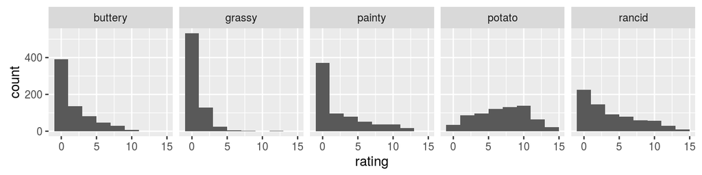

```r
ggplot(data=ff.m, aes(x=rating)) + geom_histogram(binwidth=2) +
  facet_wrap(~type, ncol=5)
```

## Side-By-Side Boxplots

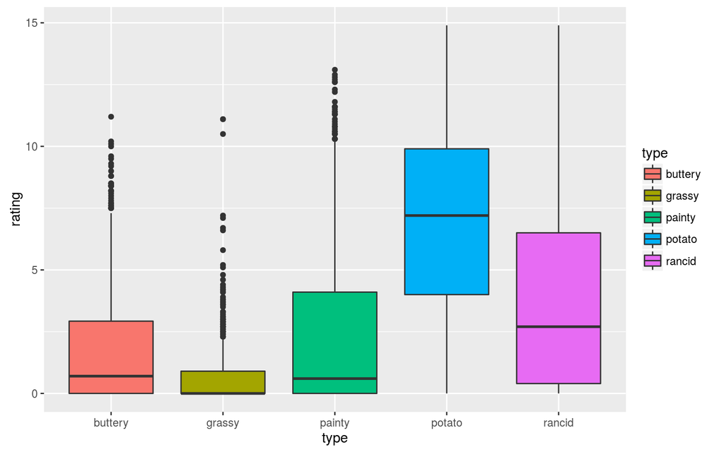

```r
ggplot(data=ff.m, aes(x=type, y=rating, fill=type)) +
  geom_boxplot()
```

## Do the Replicates Look Like Each Other?

We will start to tackle this by plotting the replicates against each other using a scatterplot.

We need to gather the data into long form, and then get the replicates spread into separate columns.

## Check Replicates

```r
head(ff.m)
```

```
#>   time treatment subject rep   type rating
#> 1    1         1       3   1 potato    2.9
#> 2    1         1       3   2 potato   14.0
#> 3    1         1      10   1 potato   11.0
#> 4    1         1      10   2 potato    9.9
#> 5    1         1      15   1 potato    1.2
#> 6    1         1      15   2 potato    8.8
```

```r
ff.s <- ff.m %>% spread(rep, rating)
head(ff.s)
```

```
#>   time treatment subject    type   1    2
#> 1    1         1       3 buttery 0.0  0.0
#> 2    1         1       3  grassy 0.0  0.0
#> 3    1         1       3  painty 5.5  0.0
#> 4    1         1       3  potato 2.9 14.0
#> 5    1         1       3  rancid 0.0  1.1
#> 6    1         1      10 buttery 6.4  5.9
```

## Check Replicates

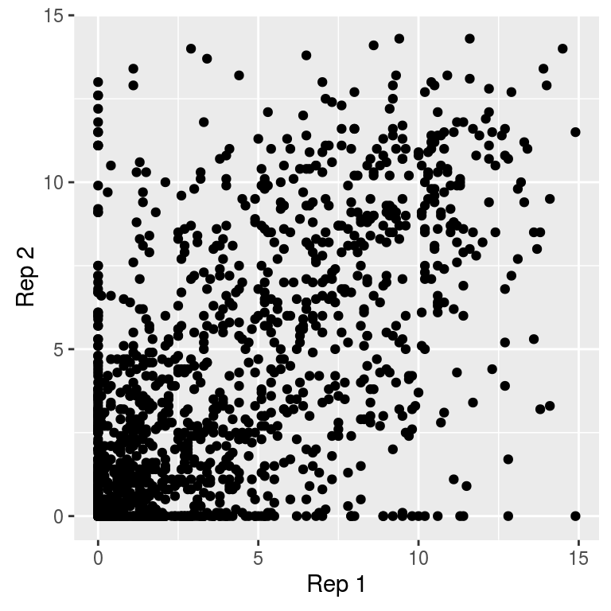

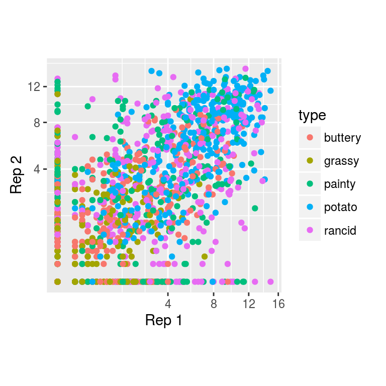

```r
ggplot(data=ff.s, aes(x=`1`, y=`2`)) + geom_point() +
  theme(aspect.ratio=1) + xlab("Rep 1") + ylab("Rep 2")
ggplot(data=ff.s, aes(x=`1`, y=`2`, color=type)) + geom_point() +
  theme(aspect.ratio=1) + xlab("Rep 1") + ylab("Rep 2") +
  scale_x_sqrt() + scale_y_sqrt()
```

## Your turn

Make the scatterplots of reps against each other separately for scales, and treatment.

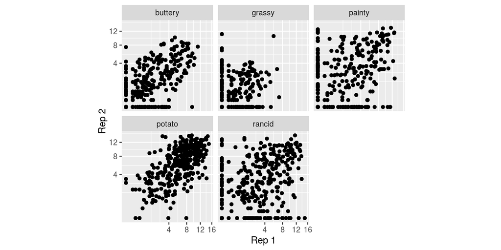

```r
ggplot(data=ff.s, aes(x=`1`, y=`2`)) + geom_point() +
  theme(aspect.ratio=1) +
  scale_x_sqrt() + scale_y_sqrt() +
  xlab("Rep 1") + ylab("Rep 2") + facet_wrap(~type, nrow=2, ncol=3)
```

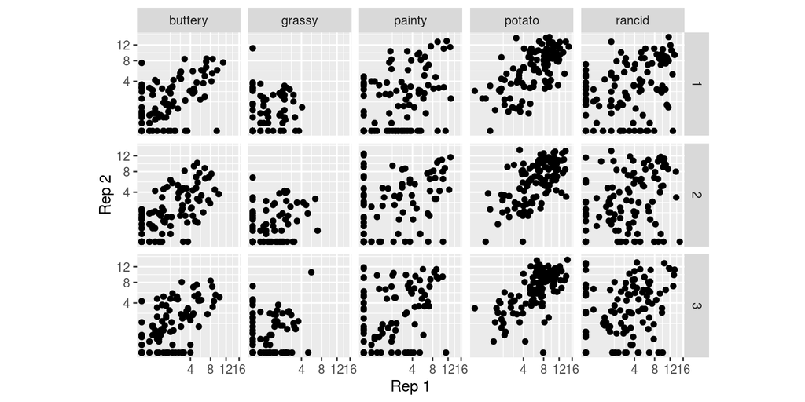

```r
ggplot(data=ff.s, aes(x=`1`, y=`2`)) + geom_point() +
  theme(aspect.ratio=1) +
  scale_x_sqrt() + scale_y_sqrt() +
  xlab("Rep 1") + ylab("Rep 2") + facet_grid(treatment~type)
```

## Your turn

Read in the billboard top 100 music data, which contains N’Sync and Backstreet Boys songs that entered the billboard charts in the year 2000

```r
billboard <- read.csv("./data/billboard.csv")
dim(billboard)
```

```
#> [1]  6 81
```

```r
colnames(billboard)
```

```
#>  [1] "year"         "artist"       "track"        "time"
#>  [5] "date.entered" "X1"           "X2"           "X3"
#>  [9] "X4"           "X5"           "X6"           "X7"
#> [13] "X8"           "X9"           "X10"          "X11"
#> [17] "X12"          "X13"          "X14"          "X15"
#> [21] "X16"          "X17"          "X18"          "X19"
#> [25] "X20"          "X21"          "X22"          "X23"
#> [29] "X24"          "X25"          "X26"          "X27"
#> [33] "X28"          "X29"          "X30"          "X31"
#> [37] "X32"          "X33"          "X34"          "X35"
#> [41] "X36"          "X37"          "X38"          "X39"
#> [45] "X40"          "X41"          "X42"          "X43"
#> [49] "X44"          "X45"          "X46"          "X47"
#> [53] "X48"          "X49"          "X50"          "X51"
#> [57] "X52"          "X53"          "X54"          "X55"
#> [61] "X56"          "X57"          "X58"          "X59"
#> [65] "X60"          "X61"          "X62"          "X63"
#> [69] "X64"          "X65"          "X66"          "X67"
#> [73] "X68"          "X69"          "X70"          "X71"
#> [77] "X72"          "X73"          "X74"          "X75"
#> [81] "X76"
```

```r
billboard[ , 1:10]
```

```
#>   year               artist                   track time date.entered X1
#> 1 2000 Backstreet Boys, The       Shape Of My Heart 3:49   2000-10-14 39
#> 2 2000 Backstreet Boys, The Show Me The Meaning ... 3:54   2000-01-01 74
#> 3 2000 Backstreet Boys, The                 The One 3:46   2000-05-27 58
#> 4 2000               N'Sync             Bye Bye Bye 3:15   2000-01-29 42
#> 5 2000               N'Sync        It's Gonna Be Me 3:10   2000-05-06 82
#> 6 2000               N'Sync      This I Promise You 4:23   2000-09-30 68
#>   X2 X3 X4 X5
#> 1 25 24 15 12
#> 2 62 55 25 16
#> 3 50 43 37 31
#> 4 20 19 14 13
#> 5 70 51 39 26
#> 6 31 19 15 11
```

```r
billboard[ , 30:41]
```

```
#>   X25 X26 X27 X28 X29 X30 X31 X32 X33 X34 X35 X36
#> 1  NA  NA  NA  NA  NA  NA  NA  NA  NA  NA  NA  NA
#> 2  NA  NA  NA  NA  NA  NA  NA  NA  NA  NA  NA  NA
#> 3  NA  NA  NA  NA  NA  NA  NA  NA  NA  NA  NA  NA
#> 4  NA  NA  NA  NA  NA  NA  NA  NA  NA  NA  NA  NA
#> 5  48  NA  NA  NA  NA  NA  NA  NA  NA  NA  NA  NA
#> 6  41  49  NA  NA  NA  NA  NA  NA  NA  NA  NA  NA
```

What’s in this data? What’s X1-X76?

position in the billboard top 100

## Your turn

1. Use `tidyr` to convert this data into a long format appropriate for plotting a time series (date on the x axis, chart position on the y axis)
2. Use `ggplot2` to create this time series plot:

```r
lf <- billboard %>% gather(week, position, -year, -artist, -track,
                           -time, -date.entered)
lf %>% head
```

```
#>   year               artist                   track time date.entered week
#> 1 2000 Backstreet Boys, The       Shape Of My Heart 3:49   2000-10-14   X1
#> 2 2000 Backstreet Boys, The Show Me The Meaning ... 3:54   2000-01-01   X1
#> 3 2000 Backstreet Boys, The                 The One 3:46   2000-05-27   X1
#> 4 2000               N'Sync             Bye Bye Bye 3:15   2000-01-29   X1
#> 5 2000               N'Sync        It's Gonna Be Me 3:10   2000-05-06   X1
#> 6 2000               N'Sync      This I Promise You 4:23   2000-09-30   X1
#>   position
#> 1       39
#> 2       74
#> 3       58
#> 4       42
#> 5       82
#> 6       68
```

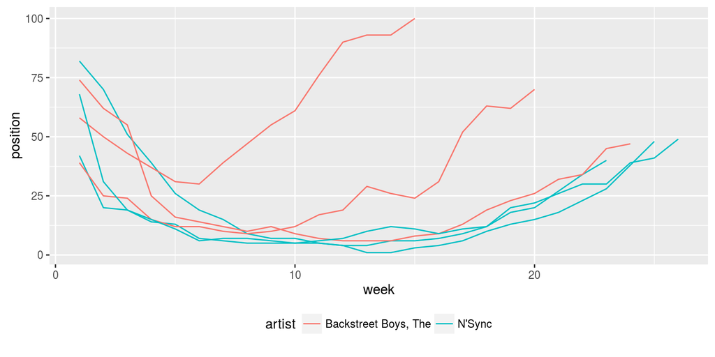

```r
lf$week <- as.numeric(gsub("X", "", lf$week))
lf <- filter(lf, !is.na(position))
ggplot(data = lf, aes(x=week, y=position, colour = artist, group = track)) + geom_line() + theme(legend.position="bottom")
```

## String Manipulation

When the experimental design is packed into column names, we need to extract it, and tidy it up.

```r
genes <- read_csv("./data/genes.csv")
head(genes)
```

```
#> # A tibble: 3 x 12
#>       id  WI-6.R1   WI-6.R2  WI-6.R4   WM-6.R1  WM-6.R2 WI-12.R1 WI-12.R2
#>    <chr>    <dbl>     <dbl>    <dbl>     <dbl>    <dbl>    <dbl>    <dbl>
#> 1 Gene 1 2.182424 2.2042219 4.195636 2.6273345 5.063641 4.540002 5.534677
#> 2 Gene 2 1.464224 0.5854472 1.859238 0.5152242 2.882808 1.364037 2.960069
#> 3 Gene 3 2.031792 0.8701078 3.281983 0.5330452 4.627315 2.182192 5.556209
#> # ... with 4 more variables: WI-12.R4 <dbl>, WM-12.R1 <dbl>,
#> #   WM-12.R2 <dbl>, WM-12.R4 <dbl>
```

## Gather Column Names into Long Form

```r
gather(genes, variable, expr, -id)
```

```
#> # A tibble: 33 x 3
#>        id variable      expr
#>     <chr>    <chr>     <dbl>
#> 1  Gene 1  WI-6.R1 2.1824242
#> 2  Gene 2  WI-6.R1 1.4642236
#> 3  Gene 3  WI-6.R1 2.0317925
#> 4  Gene 1  WI-6.R2 2.2042219
#> 5  Gene 2  WI-6.R2 0.5854472
#> 6  Gene 3  WI-6.R2 0.8701078
#> 7  Gene 1  WI-6.R4 4.1956364
#> 8  Gene 2  WI-6.R4 1.8592378
#> 9  Gene 3  WI-6.R4 3.2819835
#> 10 Gene 1  WM-6.R1 2.6273345
#> # ... with 23 more rows
```

## Separate Columns

```r
genes %>%
  gather(variable, expr, -id) %>%
  separate(variable, c("trt", "leftover"), "-")
```

```
#> # A tibble: 33 x 4
#>        id   trt leftover      expr
#> *   <chr> <chr>    <chr>     <dbl>
#> 1  Gene 1    WI     6.R1 2.1824242
#> 2  Gene 2    WI     6.R1 1.4642236
#> 3  Gene 3    WI     6.R1 2.0317925
#> 4  Gene 1    WI     6.R2 2.2042219
#> 5  Gene 2    WI     6.R2 0.5854472
#> 6  Gene 3    WI     6.R2 0.8701078
#> 7  Gene 1    WI     6.R4 4.1956364
#> 8  Gene 2    WI     6.R4 1.8592378
#> 9  Gene 3    WI     6.R4 3.2819835
#> 10 Gene 1    WM     6.R1 2.6273345
#> # ... with 23 more rows
```

```r
genes %>%
  gather(variable, expr, -id) %>%
  separate(variable, c("trt", "leftover"), "-") %>%
  separate(leftover, c("time", "rep"), "\\.")
```

```
#> # A tibble: 33 x 5
#>        id   trt  time   rep      expr
#> *   <chr> <chr> <chr> <chr>     <dbl>
#> 1  Gene 1    WI     6    R1 2.1824242
#> 2  Gene 2    WI     6    R1 1.4642236
#> 3  Gene 3    WI     6    R1 2.0317925
#> 4  Gene 1    WI     6    R2 2.2042219
#> 5  Gene 2    WI     6    R2 0.5854472
#> 6  Gene 3    WI     6    R2 0.8701078
#> 7  Gene 1    WI     6    R4 4.1956364
#> 8  Gene 2    WI     6    R4 1.8592378
#> 9  Gene 3    WI     6    R4 3.2819835
#> 10 Gene 1    WM     6    R1 2.6273345
#> # ... with 23 more rows
```

```r
gtidy <- genes %>%
  gather(variable, expr, -id) %>%
  separate(variable, c("trt", "leftover"), "-") %>%
  separate(leftover, c("time", "rep"), "\\.") %>%
  mutate(trt = gsub("W", "", trt)) %>%
  mutate(rep = as.numeric(gsub("R", "", rep)))
head(gtidy)
```

```
#> # A tibble: 6 x 5
#>       id   trt  time   rep      expr
#>    <chr> <chr> <chr> <dbl>     <dbl>
#> 1 Gene 1     I     6     1 2.1824242
#> 2 Gene 2     I     6     1 1.4642236
#> 3 Gene 3     I     6     1 2.0317925
#> 4 Gene 1     I     6     2 2.2042219
#> 5 Gene 2     I     6     2 0.5854472
#> 6 Gene 3     I     6     2 0.8701078
```

## Your turn

1. Using the tidied dataset (`gtidy`), find the mean expression for each combination of id, trt, and time.
2. Use this tidied data to make this plot.

```r
mean.expr <- gtidy %>% group_by(id, trt, time) %>%
  summarize(mean.expr=mean(expr))
head(mean.expr)
```

```
#> Source: local data frame [6 x 4]
#> Groups: id, trt [3]
#>
#>       id   trt  time mean.expr
#>    <chr> <chr> <chr>     <dbl>
#> 1 Gene 1     I    12  4.828733
#> 2 Gene 1     I     6  2.860761
#> 3 Gene 1     M    12  3.915869
#> 4 Gene 1     M     6  3.845488
#> 5 Gene 2     I    12  1.877764
#> 6 Gene 2     I     6  1.302970
```

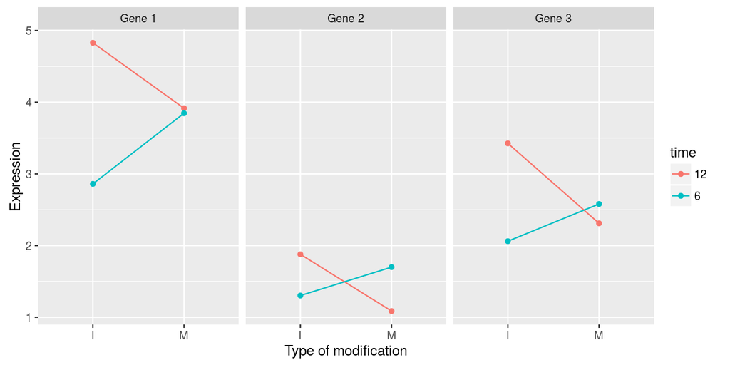

```r
ggplot(mean.expr, aes(x=trt, y=mean.expr, color=time)) +
  geom_point() + facet_wrap(~id) +
  xlab("Type of modification") + ylab("Expression") +
  geom_line(data=mean.expr, aes(group = time))
```

## Tidying model output

The package `broom` gets model results into a tidy format.

```r
ff_long <- gather(french_fries, key = variable, value =
                    rating, potato:painty)
head(ff_long, 2)
```

```
#>   time treatment subject rep variable rating
#> 1    1         1       3   1   potato    2.9
#> 2    1         1       3   2   potato   14.0
```

```r
ff_lm <- lm(rating~variable+treatment+time+subject,
            data=ff_long)
ff_lm %>% summary
```

```
#>
#> Call:
#> lm(formula = rating ~ variable + treatment + time + subject,
#>     data = ff_long)
#>
#> Residuals:
#>     Min      1Q  Median      3Q     Max
#> -7.0729 -1.9674 -0.4644  1.5202 10.2192
#>
#> Coefficients:
#>                Estimate Std. Error t value Pr(>|t|)
#> (Intercept)     1.19851    0.25792   4.647 3.50e-06 ***
#> variablegrassy -1.15513    0.15572  -7.418 1.49e-13 ***
#> variablepainty  0.70055    0.15577   4.497 7.11e-06 ***
#> variablepotato  5.13322    0.15572  32.964  < 2e-16 ***
#> variablerancid  2.03293    0.15572  13.055  < 2e-16 ***
#> treatment2     -0.05128    0.12051  -0.426   0.6705
#> treatment3     -0.04546    0.12056  -0.377   0.7062
#> time2           0.10194    0.21613   0.472   0.6372
#> time3          -0.01361    0.21613  -0.063   0.9498
#> time4          -0.10250    0.21613  -0.474   0.6353
#> time5          -0.13301    0.21690  -0.613   0.5398
#> time6          -0.04611    0.21613  -0.213   0.8311
#> time7          -0.24621    0.21628  -1.138   0.2550
#> time8          -0.11626    0.21658  -0.537   0.5914
#> time9           0.13188    0.22783   0.579   0.5627
#> time10          0.54635    0.22783   2.398   0.0165 *
#> subject10       1.71451    0.24389   7.030 2.48e-12 ***
#> subject15      -0.35911    0.24489  -1.466   0.1426
#> subject16       0.47519    0.24408   1.947   0.0516 .
#> subject19       2.01651    0.24389   8.268  < 2e-16 ***
#> subject31       1.49284    0.25098   5.948 2.98e-09 ***
#> subject51       1.87284    0.24389   7.679 2.07e-14 ***
#> subject52       0.19484    0.24389   0.799   0.4244
#> subject63       0.96051    0.24389   3.938 8.37e-05 ***
#> subject78      -0.58283    0.24389  -2.390   0.0169 *
#> subject79      -0.53702    0.25027  -2.146   0.0320 *
#> subject86       0.43543    0.25098   1.735   0.0828 .
#> ---
#> Signif. codes:  0 '***' 0.001 '**' 0.01 '*' 0.05 '.' 0.1 ' ' 1
#>
#> Residual standard error: 2.9 on 3444 degrees of freedom
#>   (9 observations deleted due to missingness)
#> Multiple R-squared:  0.3995, Adjusted R-squared:  0.395
#> F-statistic: 88.13 on 26 and 3444 DF,  p-value: < 2.2e-16
```

## Model estimates

```r
ff_lm_tidy <- tidy(ff_lm)
glimpse(ff_lm_tidy)
```

```
#> Observations: 27
#> Variables: 5
#> $ term      <chr> "(Intercept)", "variablegrassy", "variablepainty", "...
#> $ estimate  <dbl> 1.19851228, -1.15513007, 0.70054547, 5.13321525, 2.0...
#> $ std.error <dbl> 0.2579150, 0.1557200, 0.1557749, 0.1557200, 0.155720...
#> $ statistic <dbl> 4.64692727, -7.41799461, 4.49716394, 32.96439433, 13...
#> $ p.value   <dbl> 3.495385e-06, 1.489614e-13, 7.113736e-06, 2.275767e-...
```

## Model diagnostics

```r
ff_lm_all <- augment(ff_lm)
glimpse(ff_lm_all)
```

```
#> Observations: 3,471
#> Variables: 13
#> $ .rownames  <chr> "1", "2", "3", "4", "5", "6", "7", "8", "9", "10", ...
#> $ rating     <dbl> 2.9, 14.0, 11.0, 9.9, 1.2, 8.8, 9.0, 8.2, 7.0, 13.0...
#> $ variable   <chr> "potato", "potato", "potato", "potato", "potato", "...
#> $ treatment  <fctr> 1, 1, 1, 1, 1, 1, 1, 1, 1, 1, 1, 1, 1, 1, 1, 1, 1,...
#> $ time       <fctr> 1, 1, 1, 1, 1, 1, 1, 1, 1, 1, 1, 1, 1, 1, 1, 1, 1,...
#> $ subject    <fctr> 3, 3, 10, 10, 15, 15, 16, 16, 19, 19, 31, 31, 51, ...
#> $ .fitted    <dbl> 6.331728, 6.331728, 8.046235, 8.046235, 5.972622, 5...
#> $ .se.fit    <dbl> 0.2578966, 0.2578966, 0.2523712, 0.2523712, 0.25301...
#> $ .resid     <dbl> -3.4317275, 7.6682725, 2.9537651, 1.8537651, -4.772...
#> $ .hat       <dbl> 0.007910376, 0.007910376, 0.007575050, 0.007575050,...
#> $ .sigma     <dbl> 2.899486, 2.897111, 2.899641, 2.899907, 2.898931, 2...
#> $ .cooksd    <dbl> 4.169299e-04, 2.081769e-03, 2.955862e-04, 1.164238e...
#> $ .std.resid <dbl> -1.1882021, 2.6550643, 1.0225395, 0.6417396, -1.652...
```

## Residual plot

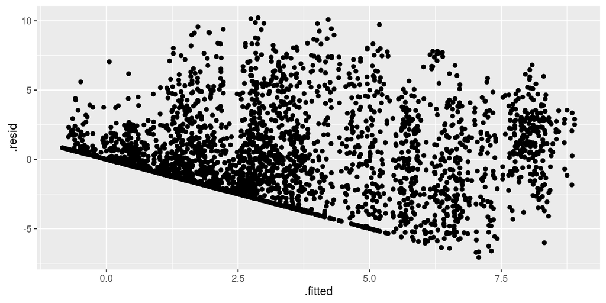

```r
ggplot(ff_lm_all, aes(x=.fitted, y=.resid)) + geom_point()
```

## Back to autism

Fit a random slopes model to the data:

$$vsae = \beta_0 + \beta_1 age2 + b_{childid} age2 + \varepsilon$$

```r
library(lme4)
data(autism)
head(autism, 3)
```

```
#>   childid sicdegp age2 vsae gender  race bestest2
#> 1       1    high    0    6   male white      pdd
#> 2       1    high    1    7   male white      pdd
#> 3       1    high    3   18   male white      pdd
```

```r
autism_keep <- autism %>% group_by(childid) %>%
  tally(sort=TRUE) %>% filter(n>2)
autism_sub <- autism %>%
  filter(childid %in% autism_keep$childid)
autism_lmer <- lmer(vsae ~ age2 + ( age2 - 1 | childid ),
                    data = autism_sub)
summary(autism_lmer)
```

```
#> Linear mixed model fit by REML ['lmerMod']
#> Formula: vsae ~ age2 + (age2 - 1 | childid)
#>    Data: autism_sub
#>
#> REML criterion at convergence: 4548.1
#>
#> Scaled residuals:
#>     Min      1Q  Median      3Q     Max
#> -3.6464 -0.3698 -0.0736  0.3172  5.3739
#>
#> Random effects:
#>  Groups   Name Variance Std.Dev.
#>  childid  age2 19.41    4.406
#>  Residual      64.92    8.057
#> Number of obs: 580, groups:  childid, 142
#>
#> Fixed effects:
#>             Estimate Std. Error t value
#> (Intercept)   9.5934     0.4821   19.90
#> age2          4.4021     0.3879   11.35
#>
#> Correlation of Fixed Effects:
#>      (Intr)
#> age2 -0.195
```

## Your turn

- Augment the autism data with the model diagnostics
- Plot the residuals from the (a) fixed, (b) random effects
- Color the residuals by (a) gender, (b) besttest2
- Plot fitted values against observed values

```r
autism_lmer_all <- augment(autism_lmer, autism_sub)
glimpse(autism_lmer_all)
```

```
#> Observations: 580
#> Variables: 17
#> $ childid  <int> 1, 1, 1, 1, 1, 10, 10, 10, 10, 100, 100, 100, 100, 10...
#> $ sicdegp  <fctr> high, high, high, high, high, low, low, low, low, hi...
#> $ age2     <dbl> 0, 1, 3, 7, 11, 0, 1, 7, 11, 0, 1, 3, 7, 0, 1, 7, 11,...
#> $ vsae     <int> 6, 7, 18, 25, 27, 9, 11, 18, 39, 15, 24, 37, 135, 8, ...
#> $ gender   <fctr> male, male, male, male, male, male, male, male, male...
#> $ race     <fctr> white, white, white, white, white, white, white, whi...
#> $ bestest2 <fctr> pdd, pdd, pdd, pdd, pdd, autism, autism, autism, aut...
#> $ .fitted  <dbl> 9.593351, 11.429607, 15.102120, 22.447145, 29.792171,...
#> $ .resid   <dbl> -3.5933508, -4.4296071, 2.8978801, 2.5528547, -2.7921...
#> $ .cooksd  <dbl> 3.585371e-04, 4.232173e-04, 1.028650e-04, 9.955294e-0...
#> $ .fixed   <dbl> 9.593351, 13.995450, 22.799648, 40.408043, 58.016439,...
#> $ .mu      <dbl> 9.593351, 11.429607, 15.102120, 22.447145, 29.792171,...
#> $ .offset  <dbl> 0, 0, 0, 0, 0, 0, 0, 0, 0, 0, 0, 0, 0, 0, 0, 0, 0, 0,...
#> $ .sqrtXwt <dbl> 1, 1, 1, 1, 1, 1, 1, 1, 1, 1, 1, 1, 1, 1, 1, 1, 1, 1,...
#> $ .sqrtrwt <dbl> 1, 1, 1, 1, 1, 1, 1, 1, 1, 1, 1, 1, 1, 1, 1, 1, 1, 1,...
#> $ .weights <dbl> 1, 1, 1, 1, 1, 1, 1, 1, 1, 1, 1, 1, 1, 1, 1, 1, 1, 1,...
#> $ .wtres   <dbl> -3.5933508, -4.4296071, 2.8978801, 2.5528547, -2.7921...
```

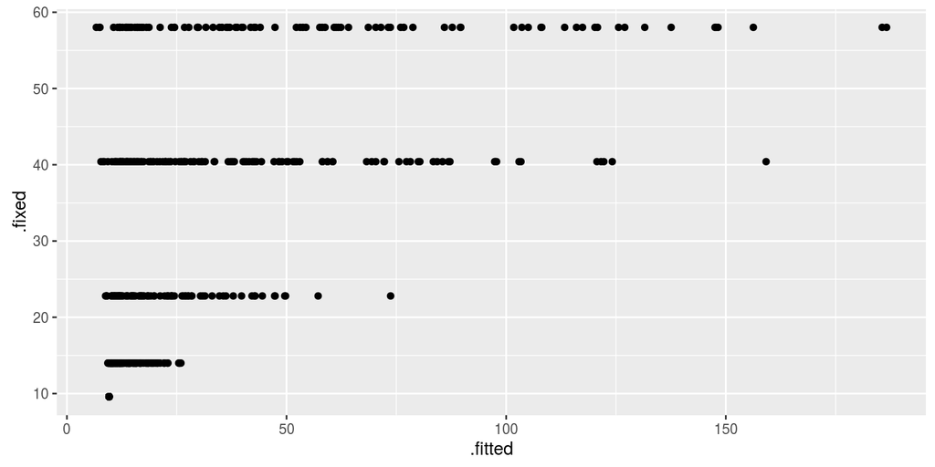

```r
ggplot(autism_lmer_all, aes(x=.fitted, y=.fixed)) + geom_point()
```

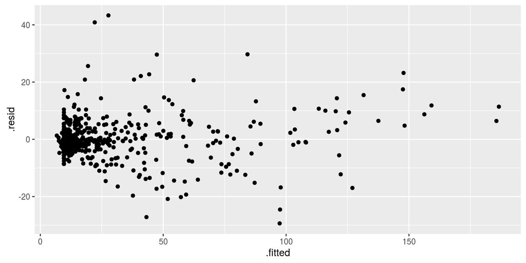

```r
ggplot(autism_lmer_all, aes(x=.fitted, y=.resid)) + geom_point()
```

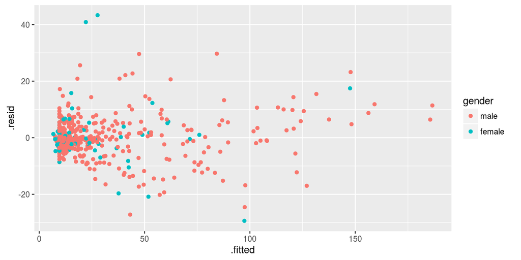

```r
ggplot(autism_lmer_all, aes(x=.fitted, y=.resid, colour=gender)) +
  geom_point()
```

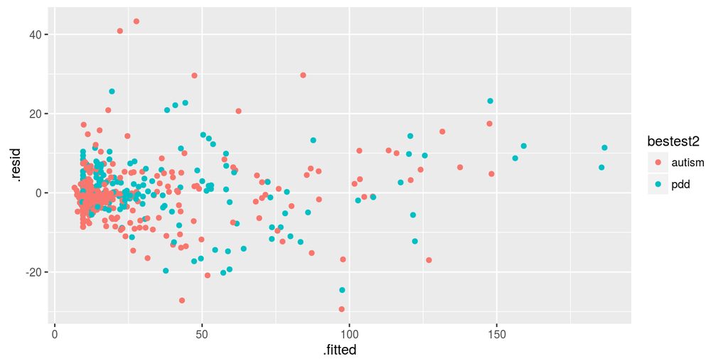

```r
ggplot(autism_lmer_all, aes(x=.fitted, y=.resid, colour=bestest2)) +
  geom_point()
```

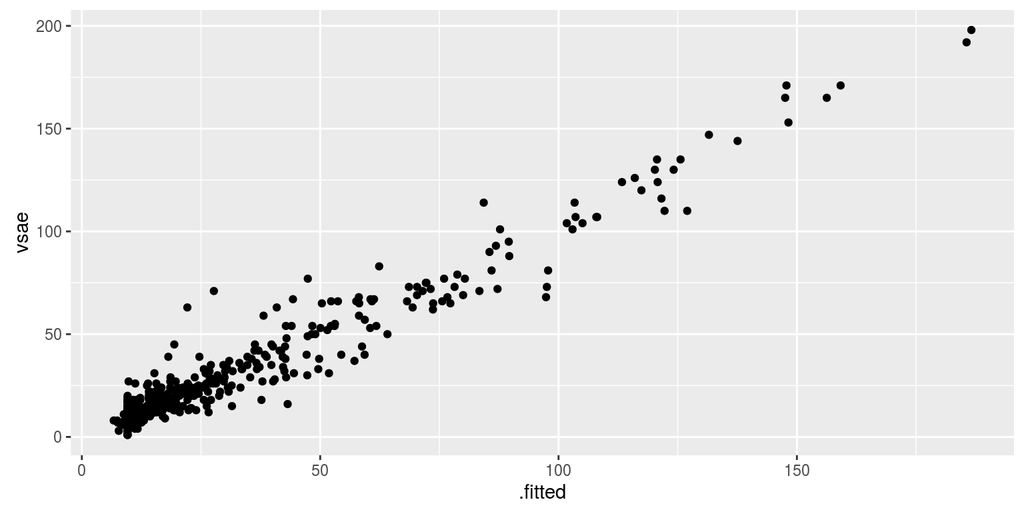

```r
ggplot(autism_lmer_all, aes(x=.fitted, y=vsae, label=childid)) +
  geom_point()
```

```r
library(plotly)
ggplotly()
```

[interactive chart not shown]

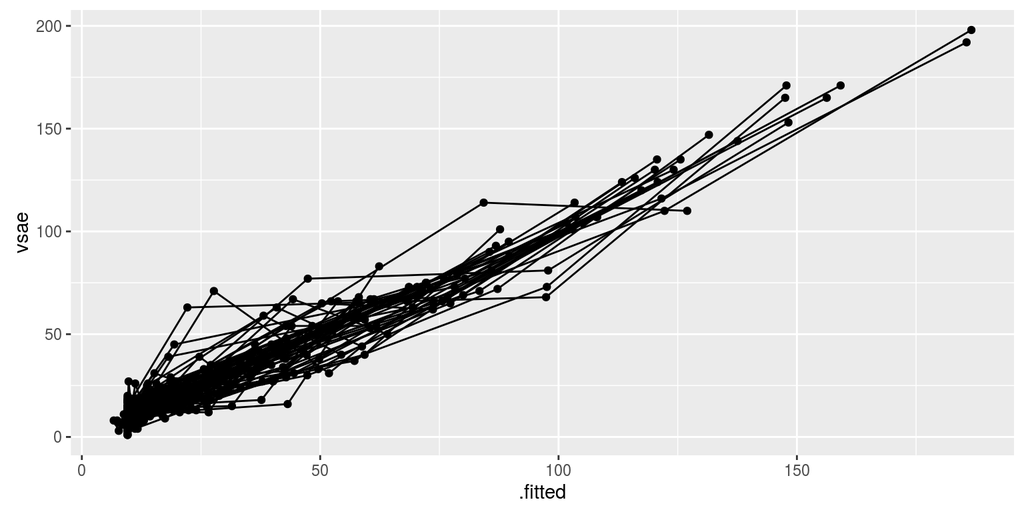

```r
ggplot(autism_lmer_all, aes(x=.fitted, y=vsae, label=childid)) +
  geom_point() + geom_line(aes(group=childid))
```

## Resources

- [tidyr and dplyr cheatsheet](http://www.rstudio.com/wp-content/uploads/2015/02/data-wrangling-cheatsheet.pdf)
- [Wickham (2007) Reshaping data](https://www.jstatsoft.org/article/view/v021i12/v21i12.pdf)
- [broom vignettes, David Robinson](https://cran.r-project.org/web/packages/broom/vignettes/broom.html)

## Share and share alike

This work is licensed under the Creative Commons Attribution-Noncommercial 3.0 United States License. To view a copy of this license, visit http://creativecommons.org/licenses/by-nc/ 3.0/us/ or send a letter to Creative Commons, 171 Second Street, Suite 300, San Francisco, California, 94105, USA.